# Project Business Statistics: E-news Express

## 1. Do the users spend more time on the new landing page than the existing landing page?

### Perform Visual Analysis

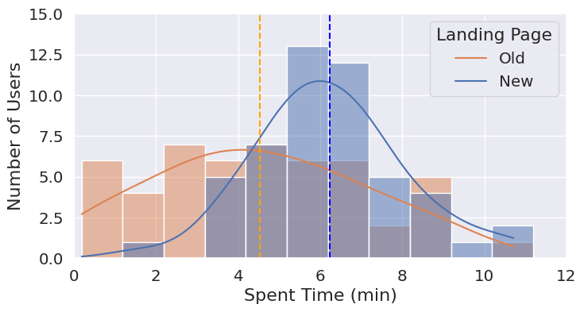

```python
plt.figure(figsize = (8,4))
sns.histplot(data = df, x = 'time_spent_on_the_page', hue = 'landing_page', kde = True, binwidth = 1)

plt.axvline(df[df.landing_page == 'old'].time_spent_on_the_page.mean(), color = "orange"
            , linestyle="--")
plt.axvline(df[df.landing_page == 'new'].time_spent_on_the_page.mean(), color = "blue"
            , linestyle="--")

plt.xlabel('Spent Time (min)', fontsize = 16);
plt.ylabel('Number of Users', fontsize = 16);
plt.xlim([0,12]);
plt.ylim([0,15]);
plt.legend(labels = ['Old','New'], title = 'Landing Page');

#The New landing page has near normal distribution, bell curved in nature....
#The Old landing page is slightly skewed to the right.
```

### Step 1: Define the null and alternate hypotheses

null hypothesis:

𝐻0: 𝜇1=𝜇2

alternative hypothesis:

Ha: 𝜇1<𝜇2

𝜇1: mean time spent on **old** landing page

𝜇2: mean time spent on **new** landing page

### Step 2: Select Appropriate test

Comparing two means (**old** and **new**) with STD unknown would require a 2-sample independent t-test.

The time data is continuous and the sample is random. This should result in fairly normal distribution.

### Step 3: Decide the significance level

The project expressed we will use a .05 significance level (95%)

### Step 4: Collect and prepare data

```python
# Create series with separated spent time data for old and new landing page users
old_spent_time = df[df.landing_page == 'old'].time_spent_on_the_page # old page users sample
new_spent_time = df[df.landing_page == 'new'].time_spent_on_the_page # new page users sample

# Find sample mean and standard deviations and print them
print('The mean of time spent by old page users is ', round(old_spent_time.mean(),2))
print('The mean of time spent by new page users is ', round(new_spent_time .mean(),2),'\n')
print('The standard deviation of time spent by old page users is ', round(old_spent_time.std(),2))
print('The standard deviation of time spent by new page users is ', round(new_spent_time.std(),2))

# The standard deviations of both sets of sample data are unequal, which could potentially mean the null hypothesis may not be found as correct.
```

```
The mean of time spent by old page users is  4.53
The mean of time spent by new page users is  6.22

The standard deviation of time spent by old page users is  2.58
The standard deviation of time spent by new page users is  1.82
```

### Step 5: Calculate the p-value

```python
from scipy.stats import ttest_ind

test_stat, p_value = ttest_ind(old_spent_time, new_spent_time, equal_var = False, alternative = 'less')

print('The p-value is found to be', p_value) # print p-value
```

```
The p-value is found to be 0.0001392381225166549
```

### Step 6: Compare the p-value with $\alpha$

```python
# (p = 0.000139) < (a = 0.05)
```

### Step 7: Draw inference

We can reject the null hypothesis as the p-value is less than that of the 0.05 level of significance. (0.000139 < 0.05) This means there is enough evidence at a 5% significance level to determine that the mean time spent by the user population directed to the **new** page is larger than that for the user population which used the **old** site.

Ha: 𝜇1<𝜇2 is correct.

**A similar approach can be followed to answer the other questions.**

## 2. Is the conversion rate (the proportion of users who visit the landing page and get converted) for the new page greater than the conversion rate for the old page?

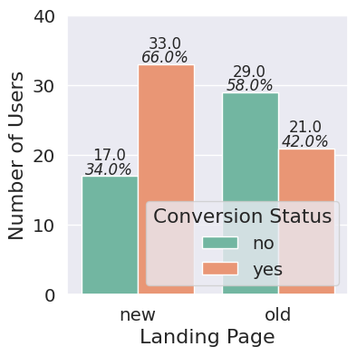

```python
plt.figure(figsize = (4,4))
p = sns.countplot(data = df, x = 'landing_page', hue = 'converted', palette = 'Set2')

p.set_xlabel("Landing Page", fontsize = 16)
p.set_ylabel("Number of Users", fontsize = 16)
p.set_ylim([0,40])
p.legend(title = 'Conversion Status', loc = 'lower right');

for pp in p.patches:
        prc = "{:.1f}%".format(100.0*pp.get_height() / (df.shape[0]/2))
        cnt = pp.get_height()

        xx = pp.get_x() + pp.get_width() / 2
        yy = pp.get_height()

        p.annotate(prc, (xx, yy), ha="center", va="center", style = 'italic', size=12, xytext=(0, 5),
                   textcoords="offset points")

        p.annotate(cnt, (xx, yy+2), ha="center", va="center", size=12, xytext=(0, 5),
                   textcoords="offset points")

#The data suggests that the new landing page generated more than 20% increase in conversion.
# Over 50% of users on the old page were not converted.
```

```python
# 66% of the users of the new page were converted, while only 42% of the users of the old landing page were converted.
```

```python
#𝑝1 = proportion of user population on the old landing page who were converted.

#𝑝2 = proportion of user population on the new landing page who were converted.

#Null hypothesis:

#𝐻0:𝑝1=𝑝2

#Alternative hypothesis:

#𝐻𝑎:𝑝1<𝑝2
```

```python
# The test will be between the proportions of two binomially distributed populations - (converted (yes) or not converted (yes) )

# The samples have been randomly selected.

# The data can be normally distributed.

# a 2-proportion z-test should be used.
```

```python
# The signifcance level is 𝛼 = 0.05
```

```python
converted_counts = np.array([len((df[df.landing_page == 'old'])[df.converted == 'yes']),
                            len((df[df.landing_page == 'new'])[df.converted == 'yes'])])

sample_sizes = np.array([50, 50])
```

```python
from statsmodels.stats.proportion import proportions_ztest

test_stat, p_value = proportions_ztest(converted_counts, sample_sizes)

print('The p-value is', p_value)
```

```
The p-value is 0.016052616408112556
```

```python
# (𝑝=0.01605)<(𝛼=0.05)

# The p-value is less than the level of significance, so we may reject the null hypothesis.
# There is enough evidence at a 5% siginifcance level to conclude that the conversion rate for the new page user population is larger than that of the old.
```

## 3. Are the conversion and preferred language independent or related?

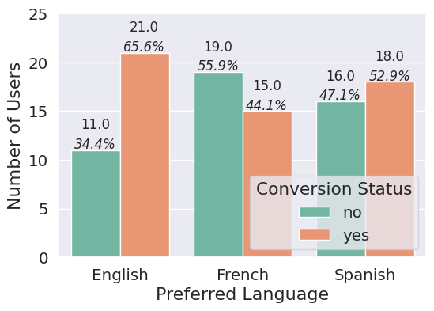

```python
plt.figure(figsize = (6,4))
p = sns.countplot(data = df, x = 'language_preferred', hue = 'converted',
                  palette = 'Set2')

p.set_xlabel("Preferred Language", fontsize = 16)
p.set_ylabel("Number of Users", fontsize = 16)
p.set_ylim([0,25])
p.legend(title = 'Conversion Status', loc = 'lower right');


for pp in p.patches[0:4:3]:
        prc = "{:.1f}%".format(100.0*pp.get_height() / df.language_preferred.value_counts()['English'])
        cnt = pp.get_height()

        xx = pp.get_x() + pp.get_width() / 2
        yy = pp.get_height()

        p.annotate(prc, (xx, yy), ha="center", va="center", style = 'italic', size=12, xytext=(0, 5),
                   textcoords="offset points")

        p.annotate(cnt, (xx, yy+2), ha="center", va="center", size=12, xytext=(0, 5),
                   textcoords="offset points")

for pp in p.patches[1:5:3]:
        prc = "{:.1f}%".format(100.0*pp.get_height() / df.language_preferred.value_counts()['French'])
        cnt = pp.get_height()

        xx = pp.get_x() + pp.get_width() / 2
        yy = pp.get_height()

        p.annotate(prc, (xx, yy), ha="center", va="center", style = 'italic', size=12, xytext=(0, 5),
                   textcoords="offset points")

        p.annotate(cnt, (xx, yy+2), ha="center", va="center", size=12, xytext=(0, 5),
                   textcoords="offset points")

for pp in p.patches[2:6:3]:
        prc = "{:.1f}%".format(100.0*pp.get_height() / df.language_preferred.value_counts()['Spanish'])
        cnt = pp.get_height()

        xx = pp.get_x() + pp.get_width() / 2
        yy = pp.get_height()

        p.annotate(prc, (xx, yy), ha="center", va="center", style = 'italic', size=12, xytext=(0, 5),
                   textcoords="offset points")

        p.annotate(cnt, (xx, yy+2), ha="center", va="center", size=12, xytext=(0, 5),
                   textcoords="offset points")
```

```python
# Based off of the graph above, the conversion rate and preferred language may be related.
```

```python
# Null hypothesis:

# 𝐻0: User conversion rate is independent of their preferred language.

# Alternative hypothesis:

# 𝐻𝑎: User conversion rate is dependent on their preferred language.

# The problem is determining whether two categorical variables are related or independent.
# The observations in each group are above 5 and the samples have been randomly selected.

# Chi-squared test is proper.

# Significance level is still a = 0.05
```

```python
contingency_table = pd.crosstab(df.language_preferred, df.converted)
contingency_table
```

| converted language_preferred | no | yes |
| --- | --- | --- |
| English | 11 | 21 |
| French | 19 | 15 |
| Spanish | 16 | 18 |

```python
from scipy.stats import chi2_contingency

chi, p_value, dof, expected = chi2_contingency(contingency_table)

print('The p-value is ', p_value)
```

```
The p-value is  0.2129888748754345
```

```python
# (p = 0.21299) > (a = 0.05)

# We may not reject the null hypothesis, as the p-value found is larger than the level of significance (p = 0.21299) > (a = 0.05).
#As a result there is not enough evidence at a 5% signicance level to conclude that the conversion rates are related to the preferred languages.
```

## 4. Is the time spent on the new page same for the different language users?

```python
df_new_page = df[df.landing_page == 'new']
```

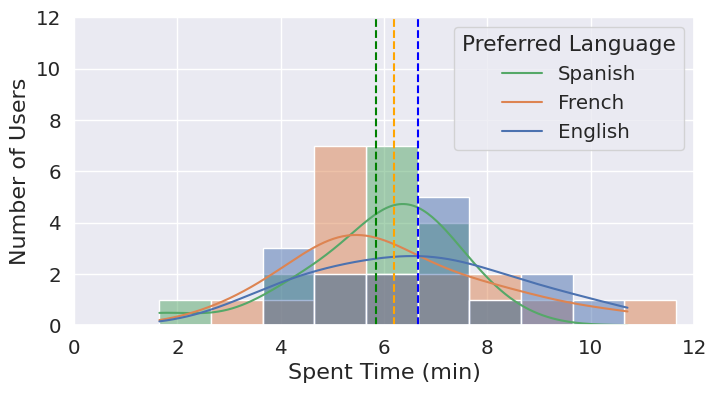

```python
plt.figure(figsize = (8,4))
sns.histplot(data = df_new_page, x = 'time_spent_on_the_page', hue = 'language_preferred', kde = True, binwidth = 1)
plt.axvline(df_new_page[df_new_page.language_preferred == 'English'].time_spent_on_the_page.mean(), color = "blue"
            , linestyle="--")
plt.axvline(df_new_page[df_new_page.language_preferred == 'French'].time_spent_on_the_page.mean(), color = "orange"
            , linestyle="--")
plt.axvline(df_new_page[df_new_page.language_preferred == 'Spanish'].time_spent_on_the_page.mean(), color = "green"
            , linestyle="--")

plt.xlabel('Spent Time (min)', fontsize = 16);
plt.ylabel('Number of Users', fontsize = 16);
plt.xlim([0,12]);
plt.ylim([0,12]);
plt.legend(labels = ['Spanish','French','English'], title = 'Preferred Language');

# The mean time spent for users on the new page preferring different languages seem to be slightly different.
```

```python
# 𝜇1 = English user population mean time spent on the new page.
# 𝜇2 = French user population mean time spent on the new page.
# 𝜇3 = Spanish user population mean time spent on the new page.

# Null Hypothesis:

# 𝐻0:𝜇1=𝜇2=𝜇3

# Alternative Hypothesis

# 𝐻𝑎: At least one of the populations has a different mean time spent from others.
```

```python
# We must compare the means of three independent populations of continuous variables.
# The populations are normally distributed. (If Shapiro-Wilk and Levene's tests express so.)
# The samples have been randomly selected.

# Then One-way ANOVA test will compare population means.
```

```python
# Null hypothesis for Shapiro-Wilk's Test:

# 𝐻0: Spent time follows a normal distribution.

# Alternative Hypothesis for Shapiro-Wilk's Test:

# 𝐻𝑎: Spent time does not follow a normal distribution.
```

```python
w, p_value = stats.shapiro(df_new_page.time_spent_on_the_page)

print('The p-value is', p_value)
```

```
The p-value is 0.8040016293525696
```

```python
# p-value (0.80400) > level of significance (0.05), the null hypthesis cannot be rejected, so normality can be assumed.
```

```python
# Null Hypothesis for Levene's test:

# 𝐻0: Variances of populations time spent are equal.

# Alternative Hypothesis for Levene's test:

#𝐻𝑎: At least the variance of one of populations time spent is different from others'.
```

```python
w, p_value = stats.levene(df_new_page.time_spent_on_the_page[df_new_page.language_preferred == 'English'],
                         df_new_page.time_spent_on_the_page[df_new_page.language_preferred == 'French'],
                         df_new_page.time_spent_on_the_page[df_new_page.language_preferred == 'Spanish'])

print('The p-value is found to be', p_value)
```

```
The p-value is found to be 0.46711357711340173
```

```python
# p-value (0.467) > level of significance (0.05)
# Since the p-value is much larger than the level of significance the null hypothesis cannot be rejected.
# The variance equality assumption holds.
```

```python
# The significance level as per problem listed is 𝛼 = 0.05.
```

```python
spent_time_English = df_new_page.time_spent_on_the_page[df_new_page.language_preferred == 'English']
spent_time_French = df_new_page.time_spent_on_the_page[df_new_page.language_preferred == 'French']
spent_time_Spanish = df_new_page.time_spent_on_the_page[df_new_page.language_preferred == 'Spanish']
```

```python
test_stat, p_value = stats.f_oneway(spent_time_English,spent_time_French, spent_time_Spanish)

print('The p-value is ', p_value)
```

```
The p-value is  0.43204138694325955
```

```python
# p-value (0.432) > (0.05)

# The p-value is much larger than the level of significance which means we cannot reject the null hypothesis.
# There is not enough evidence at a 5% significance level to conclude that the time spent on the page is related to the preferred language.
```

## Conclusion and Business Recommendations

Exploratory Data Analysis (EDA):

The mean and median of time spent on landing page by the sampled users is close to 5.4 minutes. The maximum time spent by the users is 10.7 minutes.

I would recommend trialing another two site pages, using the "new" from this analysis and adding a "newer" option which adds more of what already exists on the "new" page....possibly brighter colors / eye catching photos, or extremely clickable headlines.

54% of the sampled users have converted to subscribers.

I would be curious to determine whether the "subscribe" button is in a visible enough location and font style on the site page, i'd also want to determine if there was an additional "subscribe" pop-up.

The language options (English, French, and Spanish) are preferred by similar proportions of users (32%, 34%, and 34%).

E-News is doing a proper job in maintaining accessiblity to diverse readers. I would suggest determining a fourth language for their audience by testing it in a few different markets...based off of the intel we recieved a fourth language could potentially have a similar outcome to the other three, although independent from each other.

Users landing on the new page spent a longer time on the portal than the users landing on the old page.

I would attempt a larger sample to verify, but the new user landing page could potentially be much more auspicous than the old.

Time spent by users with various language preferences have close means. This indicates that the language preference may be insignificant on the users' attraction to the portal.

The users who converted to subscribers on average spent more time on the portal. This finding was predicted and implies that the longer the news pages keep the users interest, the higher the likelihood of a subscription.